# Project: Systemic And Banking Crisis.

### **Title**: Study the effect of developed countries (USA) on developing (Egypt).

## Table of Contents:

- Introduction
- View Data
- Conclusions

## Introduction

> **Systemic And Banking Crisis** This data contains the Systemic and the banking crises of 70 countries, from 1800 AD to 2016 AD, with a total of 8642 records and 17 variables.

### **Variable | Description***:

- **1-Case**: ID Number for Country.
- **2-Cc3**: ID String for Country.
- **3-Country**: Name Country.
- **4-Yea**: The date from 1800 to 2016.
- **5-Banking_Crisis**: Banking problems can often be traced to a decrease the value of banks' assets:
  > - A) due to a collapse in real estate prices or When the bank asset values decrease substantially.
  > - B) if a government stops paying its obligations, this can trigger a sharp decline in value of bonds.
- **6-Systemic_Crisis**: When many banks in a country are in serious solvency or liquidity problems at the same time—either:
  > - A) because there are all hits by the same outside shock.
  > - B) or because failure in one bank or a group of banks spreads to other banks in the system.
- **7-Gold_Standard**: The Country have crisis in Gold Standard.
- **8-Exch_Usd**: Exch local currency in USD, Except exch USD currency in GBP.
- **9-Domestic_Debt_In_Default**: The Country have domestic debt in default.
- **10-Sovereign_External_Debt_1**: Default and Restructurings, 1800-2012--Does not include defaults on WWI debt to United States and United Kingdom and post-1975 defaults on Official External Creditors.
- **11-Sovereign_External_Debt_2**: Default and Restructurings, 1800-2012--Does not include defaults on WWI debt to United States and United Kingdom but includes post-1975 defaults on Official External Creditors.
- **12-Gdp_Weighted_Default**: GDP Weighted Default for country.
- **13-Inflation**: Annual percentages of average consumer prices.
- **14-Independence**: Independence for country.
- **15-Currency_Crises**: The Country have crisis in Currency.
- **16-Inflation_Crises**: The Country have crisis in Inflation.
- **17-Level_Country**: The description of the country whether it's Developing or Developed.

## **Research Questiones**:-

Research Question 1 : Does the occurrence of a Systemic Crisis in US leads to its occurrence in Egypt?

Research Question 2 : Does Does the occurrence of a Banking Crisis in US leads to its occurrence in Egypt?

Research Question 3 : Does the occurrence of a Gold Standard in US leads to its occurrence in Egypt?

Research Question 4 : Does the occurrence of a Domestic Debt In Default in US leads to its occurrence in Egypt?

Research Question 5 : Does the occurrence of a Sovereign External Debt 1 in US leads to its occurrence in Egypt?

Research Question 6 : Does the occurrence of a Sovereign External Debt 2 in US leads to its occurrence in Egypt?

Research Question 7 : Does the occurrence of a Currency Crises in US leads to its occurrence in Egypt?

Research Question 8 : Does the occurrence of a Inflation Crises in US leads to its occurrence in Egypt?

Research Question 9 : Does Exchange `USD` by `GBP` affect in Exchange `EGP` by `USD`??

Research Question 10 : Does the occurrence of a different in GDP Weighted Default in US leads to its occurrence in Egypt?

Research Question 11 : Does there a interconnection between the occurrence of Inflation in US and its occurrence in Egypt?

## Systemic_Crisis

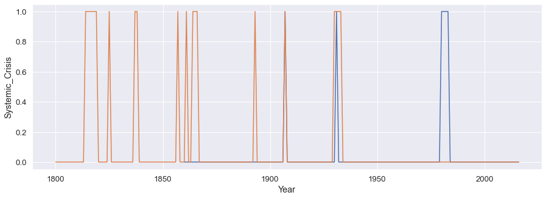

```python
sns.lineplot(data=df_egypt,x="Year",y="Systemic_Crisis")
sns.lineplot(data=df_us,x="Year",y="Systemic_Crisis");
```

### The occurrence of a `Systemic Crisis` in `US` leads to its occurrence in `Egypt`.

## Banking_Crisis

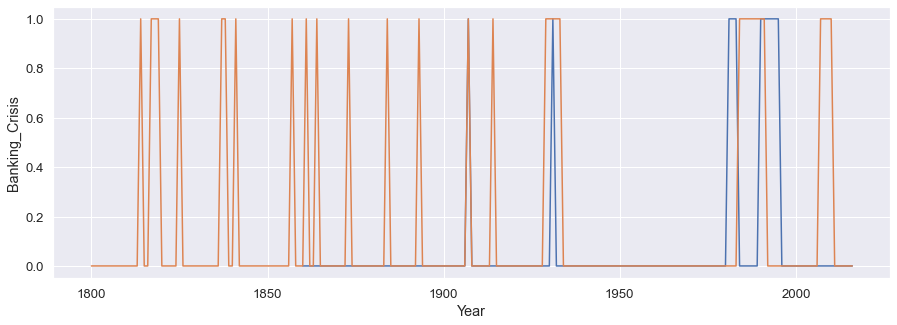

```python
sns.lineplot(data=df_egypt,x="Year",y="Banking_Crisis")
sns.lineplot(data=df_us,x="Year",y="Banking_Crisis");
```

### The occurrence of a `Banking Crisis` in `US` leads to its occurrence in `Egypt`.

## Gold_Standard

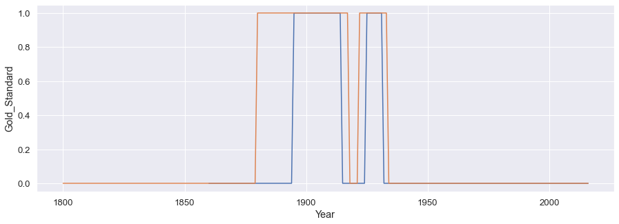

```python
sns.lineplot(data=df_egypt,x="Year",y="Gold_Standard")
sns.lineplot(data=df_us,x="Year",y="Gold_Standard");
```

### The occurrence of a Crisis in `Gold Standard` in `US` leads to its occurrence in `Egypt`.

### Domestic_Debt_In_Default

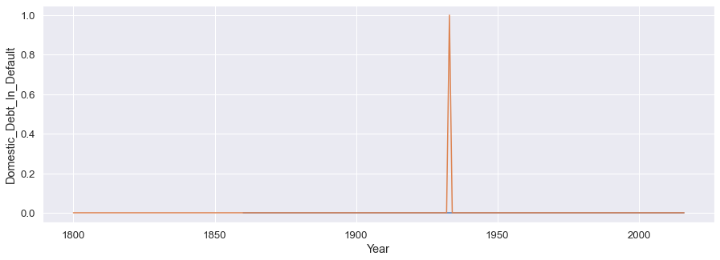

```python
sns.lineplot(data=df_egypt,x="Year",y="Domestic_Debt_In_Default")
sns.lineplot(data=df_us,x="Year",y="Domestic_Debt_In_Default");
```

### The occurrence of a Crisis in `Domestic Debt In Default` in `US` does not leads to its occurrence in `Egypt`.

## Sovereign_External_Debt_1

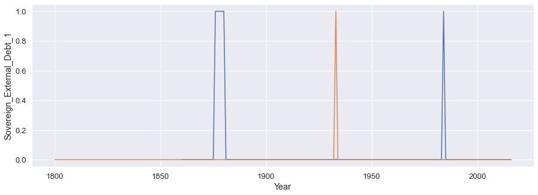

```python
sns.lineplot(data=df_egypt,x="Year",y="Sovereign_External_Debt_1")
sns.lineplot(data=df_us,x="Year",y="Sovereign_External_Debt_1");
```

### The occurrence of a Crisis in `Sovereign External Debt 1` in `US` does not leads to its occurrence in `Egypt`.

## Sovereign_External_Debt_2

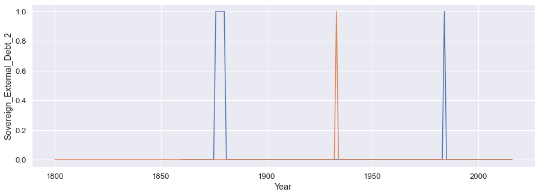

```python
sns.lineplot(data=df_egypt,x="Year",y="Sovereign_External_Debt_2")
sns.lineplot(data=df_us,x="Year",y="Sovereign_External_Debt_2");
```

### The occurrence of a Crisis in `Sovereign External Debt 2` in `US` does not leads to its occurrence in `Egypt`.

## Currency_Crises

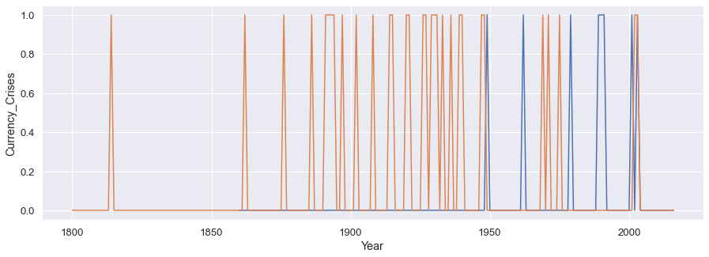

```python
sns.lineplot(data=df_egypt,x="Year",y="Currency_Crises")
sns.lineplot(data=df_us,x="Year",y="Currency_Crises");
```

### The occurrence of a `Currency Crises` in `US` sometimes leads to its occurrence in `Egypt`.

## Inflation_Crises

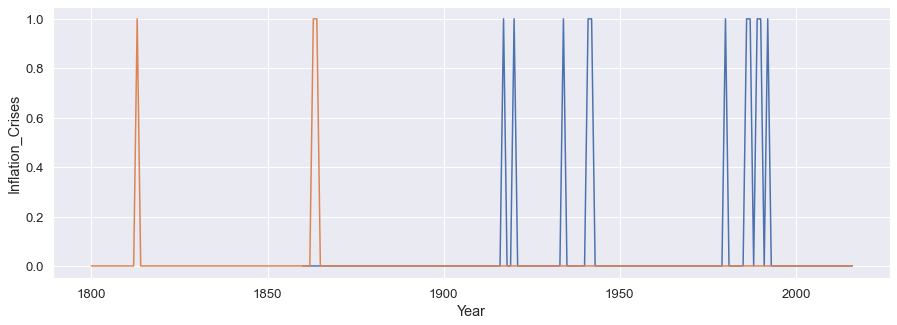

```python
sns.lineplot(data=df_egypt,x="Year",y="Inflation_Crises")
sns.lineplot(data=df_us,x="Year",y="Inflation_Crises");
```

### The occurrence of a Crisis in `Inflation Crises` in `US` does not leads to its occurrence in `Egypt`.

## Exch_Usd

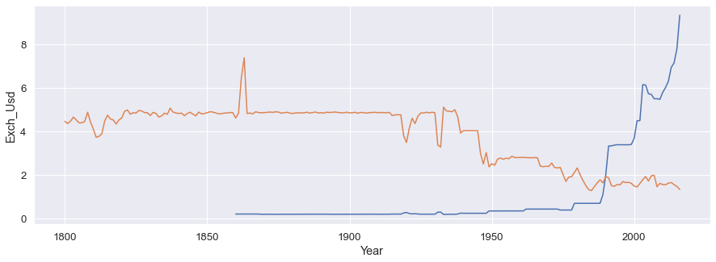

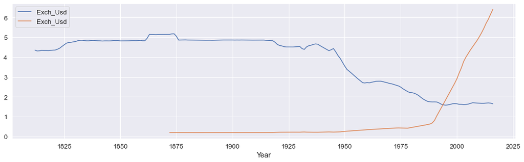

```python
sns.lineplot(data=df_egypt,x="Year",y="Exch_Usd")
sns.lineplot(data=df_us,x="Year",y="Exch_Usd");
pd.concat([df_us["Exch_Usd"].rolling(13).mean(),df_egypt["Exch_Usd"].rolling(13).mean()],axis=1).plot(figsize=(18,5));
```

### Exchange{ `USD` by `GBP`} affect in Exchange {`EGP` by `USD`}.

> - That is, the `high` the value of the `USD`, the `low` the value of the `EGP`.

## Gdp_Weighted_Default

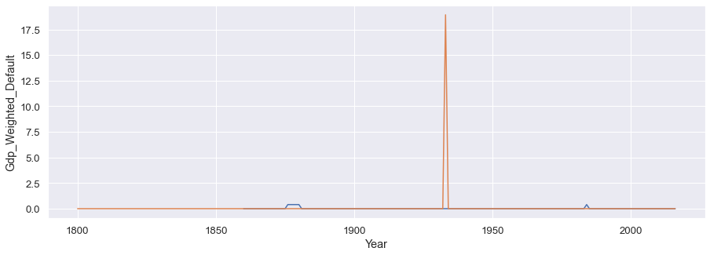

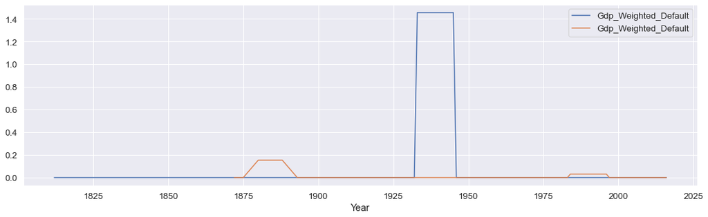

```python
sns.lineplot(data=df_egypt,x="Year",y="Gdp_Weighted_Default")
sns.lineplot(data=df_us,x="Year",y="Gdp_Weighted_Default");
pd.concat([df_us["Gdp_Weighted_Default"].rolling(13).mean(),df_egypt["Gdp_Weighted_Default"].rolling(13).mean()],axis=1).plot(figsize=(18,5));
```

### The occurrence of a different in `GDP Weighted Default` in `US` does not leads to its occurrence in `Egypt`.

## Inflation

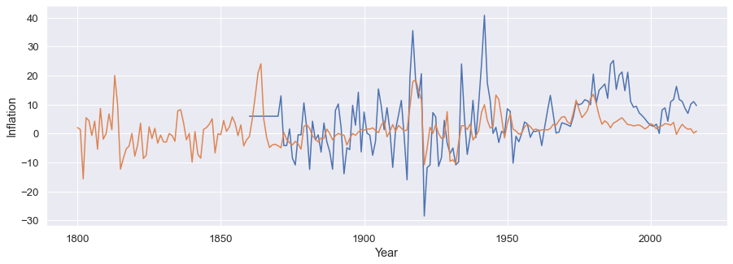

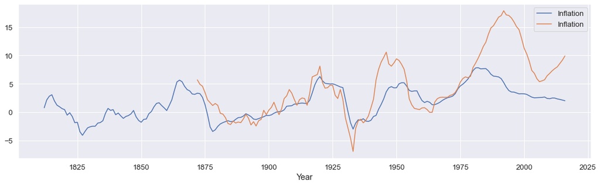

```python
sns.lineplot(data=df_egypt,x="Year",y="Inflation")
sns.lineplot(data=df_us,x="Year",y="Inflation");
pd.concat([df_us["Inflation"].rolling(13).mean(),df_egypt["Inflation"].rolling(13).mean()],axis=1).plot(figsize=(18,5));
```

#### There a interconnection between the occurrence of `Inflation` in `US` and its occurrence in `Egypt`.

# view Data

#### `Sys_Ban_Crisis`

> - `not` Systemic_Crisis And with `not` Banking_Crisis >>>`N`
> - `not` Systemic_Crisis And with Banking_Crisis >>>`B`
> - Systemic_Crisis And with `not` Banking_Crisis >>>`S`
> - Systemic_Crisis And with Banking_Crisis >>>`SB`

```
>- not` Systemic_Crisis And with `not` Banking_Crisis >>>`N`= 7805
>- `not` Systemic_Crisis And with Banking_Crisis >>>`B`= 300
>- Systemic_Crisis And with `not` Banking_Crisis >>>`S`= 49
>- Systemic_Crisis And with Banking_Crisis >>>`SB`= 488
```

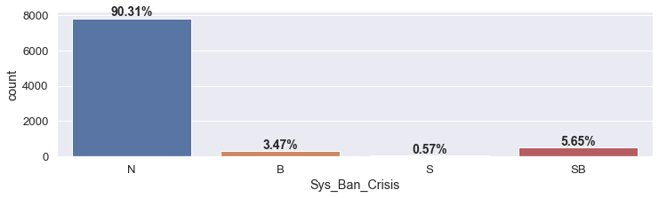

```python
CountPercent(df,"Sys_Ban_Crisis",fig=[12, 3])

n,sb,b,s=df["Sys_Ban_Crisis"].value_counts()
print(f""">- not` Systemic_Crisis And with `not` Banking_Crisis >>>`N`= {n}
>- `not` Systemic_Crisis And with Banking_Crisis >>>`B`= {b}
>- Systemic_Crisis And with `not` Banking_Crisis >>>`S`= {s}
>- Systemic_Crisis And with Banking_Crisis >>>`SB`= {sb}""")
```

```python
plotly.offline.plot(fig,filename="History.html",auto_open=True)
```

```
'History.html'
```

## Conclusions

### From the information above it becomes clear that:

### (1)

> - The occurrence of a {Systemic Crisis,Banking Crisis,Gold Standard,Currency Crises} in `US` leads to its `occurrence` in `Egypt`. -There a interconnection between the occurrence of `Inflation` in `US` and its occurrence in `Egypt`.

### (2)

> - The occurrence of a Crisis in {Domestic Debt In Default,Sovereign External Debt 1,Sovereign External Debt 2,Inflation Crises,a different in GDP Weighted Default } in `US` does `not leads` to its occurrence in `Egypt`.

### (3)

> - Exch {`USD` by `GBP`} affect in Exch {`EGP` by `USD`}.
>   > - That is, the `high` the value of the `USD`, the `low` the value of the `EGP`.